# MLProject

# Practical Machine Learning Project

## Data processing

First we need to load the data:

```r
train=read.csv("pml-training.csv")
classe = as.factor(train$classe)

#Keep numeric variables
train.num = train[,sapply(train,is.numeric)]

#Perform PCA analysis to reduce number of variables
library(caret)
preproc = preProcess(train.num,method='pca',pcaComp=10)
train.pca = predict(preproc,train.num)
train.pca = cbind(train.pca,classe)

#Split into train and test for building the model and performing out of sample error
library(caTools)
split=sample.split(train.pca$classe,SplitRatio = 0.7)
train.pca = subset(train.pca,split==1)
test.pca = subset(train.pca,split==0)



#In order to predict for the 20 test cases we need to perform the same changes to the test dataframe:

test20=read.csv("pml-testing.csv")

#Keep numeric variables
test20.num = test20[,sapply(test20,is.numeric)]

#Perform PCA analysis to reduce number of variables
preproc20 = preProcess(test20.num,method='pca',pcaComp=10)
test20.pca = predict(preproc20,test20.num)
```

## Model building

Looking at the data we can see there are different types of variables and a large number of them. The easiest way to implement a machine learning algorithm would be a tree or a random forest (these algortihms automatically select which variables are more important).

We are going to train a classification tree despite of being less accurate than the random forest. This is done mainly for computation issues (very slow computer). As the purpose of this project is to demonstrate the capability of builiding a machine learning model the accuracy does not matter a lot.

### Cross validation

In order to perform cross-validation we are goin to tune the complexity parameter, to reduce the complexity of the model when needed. Any split that does not decrease the overall lack of fit by a factor of cp is not attempted.

```r
# Load cross-validation packages
library(caret)
library(e1071)

# Define cross-validation experiment
fitControl = trainControl( method = "cv", number = 10 )
cartGrid = expand.grid( .cp = (1:50)*0.01)

# Perform the cross validation
train(classe ~ ., data = train.pca, method = "rpart", trControl = fitControl, tuneGrid = cartGrid )
```

```
## CART
##
## 13735 samples
##    10 predictors
##     5 classes: 'A', 'B', 'C', 'D', 'E'
##
## No pre-processing
## Resampling: Cross-Validated (10 fold)
##
## Summary of sample sizes: 251, 252, 250, 250, 251, 251, ...
##
## Resampling results across tuning parameters:
##
##   cp    Accuracy  Kappa  Accuracy SD  Kappa SD
##   0.01  0.5       0.4    0.09         0.1
##   0.02  0.5       0.4    0.09         0.1
##   0.03  0.5       0.4    0.1          0.1
##   0.04  0.5       0.3    0.08         0.09
##   0.05  0.5       0.3    0.07         0.08
##   0.06  0.5       0.3    0.07         0.08
##   0.07  0.5       0.3    0.06         0.07
##   0.08  0.5       0.3    0.06         0.07
##   0.09  0.5       0.3    0.07         0.09
##   0.1   0.4       0.3    0.1          0.1
##   0.1   0.4       0.2    0.06         0.08
##   0.1   0.4       0.2    0.04         0.06
##   0.1   0.3       0.1    0.05         0.08
##   0.1   0.3       0.09   0.06         0.09
##   0.2   0.3       0.05   0.04         0.07
##   0.2   0.3       0.02   0.03         0.05
##   0.2   0.3       0.01   0.03         0.05
##   0.2   0.2       0      0.01         0
##   0.2   0.2       0      0.01         0
##   0.2   0.2       0      0.01         0
##   0.2   0.2       0      0.01         0
##   0.2   0.2       0      0.01         0
##   0.2   0.2       0      0.01         0
##   0.2   0.2       0      0.01         0
##   0.2   0.2       0      0.01         0
##   0.3   0.2       0      0.01         0
```

[output cut: 12 more lines]

```
##   0.4   0.2       0      0.01         0
##   0.4   0.2       0      0.01         0
##   0.4   0.2       0      0.01         0
##   0.4   0.2       0      0.01         0
##   0.4   0.2       0      0.01         0
##   0.4   0.2       0      0.01         0
##   0.4   0.2       0      0.01         0
##   0.5   0.2       0      0.01         0
##   0.5   0.2       0      0.01         0
##   0.5   0.2       0      0.01         0
##   0.5   0.2       0      0.01         0
##   0.5   0.2       0      0.01         0
##
## Accuracy was used to select the optimal model using  the largest value.
## The final value used for the model was cp = 0.01.
```

Having selected the complexity parameter with the lowest cross-validated error we can now build our model and predict the outcome for the Test cases:

```r
# Create a new CART model
library(rpart)
TreeCV = rpart(classe ~ ., method="class", data = train.pca, control=rpart.control(cp = 0.01))

# Make predictions
PredictCV = predict(TreeCV, newdata = test.pca, type = "class")

library(rattle)
```

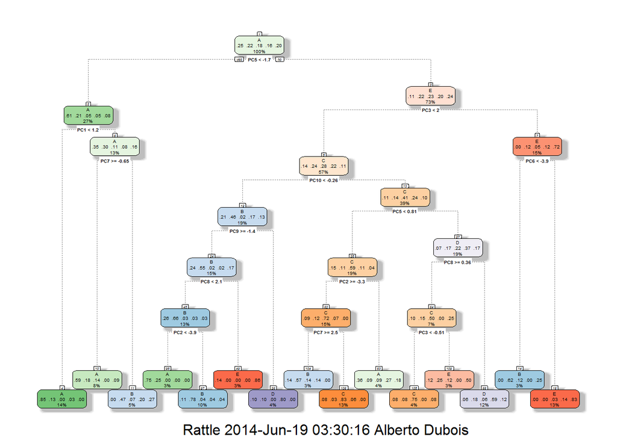

```r
fancyRpartPlot(TreeCV)
```

### Accuracy out of sample error

```r
library(caret)
confusionMatrix(test.pca$classe,PredictCV)
```

```
## Confusion Matrix and Statistics
##
##           Reference
## Prediction    A    B    C    D    E
##          A   14    0 1154    0    0
##          B    4    6  800    2    0
##          C    2    0  698    1    2
##          D    0    3  682    7    3
##          E    0    3  736    1   18
##
## Overall Statistics
##
##                Accuracy : 0.18
##                  95% CI : (0.168, 0.192)
##     No Information Rate : 0.984
##     P-Value [Acc > NIR] : 1
##
##                   Kappa : 0.011
##  Mcnemar's Test P-Value : NA
##
## Statistics by Class:
##
##                      Class: A Class: B Class: C Class: D Class: E
## Sensitivity           0.70000  0.50000   0.1715  0.63636  0.78261
## Specificity           0.71963  0.80456   0.9242  0.83321  0.82008
## Pos Pred Value        0.01199  0.00739   0.9929  0.01007  0.02375
## Neg Pred Value        0.99798  0.99819   0.0178  0.99884  0.99852
## Prevalence            0.00484  0.00290   0.9840  0.00266  0.00556
## Detection Rate        0.00338  0.00145   0.1688  0.00169  0.00435
## Detection Prevalence  0.28240  0.19632   0.1700  0.16804  0.18327
## Balanced Accuracy     0.70982  0.65228   0.5479  0.73479  0.80135
```

## Predictions for the 20 test samples

```r
Predict20 = predict(TreeCV, newdata = test20.pca, type = "class")
Predict20
```

```
##  1  2  3  4  5  6  7  8  9 10 11 12 13 14 15 16 17 18 19 20
##  C  E  C  A  E  C  B  C  B  B  D  C  A  D  A  B  B  B  D  C
## Levels: A B C D E
```